# Lab 6

JT McCrone

October 1, 2014

Before diving into this analysis I’d like to note that I in general I understand the processes involved in modeling these populations; however we start comparing the model with the anova generated statistics I start to get a little hazzy. I also think I could use some feedback on my comments regarding the biological interpretations of the statistics and the validity of our assumptions. I look forward to making adjustments to this assingment as my understanding of the material improves.

We’ll start by loading the data.

```r
options(stringsAsFactors = FALSE)
course.url <- "http://kinglab.eeb.lsa.umich.edu/480"
urls <- paste0(course.url,"/data/",
               c("Thrips_imaginis_Davidson1948.csv",
                 "Parus_major_Wytham_Wood.csv"))
dat <- lapply(urls,read.csv,comment.char="#")
require(plyr)
thrips <- mutate(dat[[1]],
                 year=Sample.Date%/%1,
                 month=round(100*(Sample.Date%%1)),
                 time=year+month/12,
                 pop=Population, Population=NULL, Sample.Date=NULL)
parus <- rename(dat[[2]],c(Sample.Date="year",Population="pop"))
rm(dat)
```

### Exercise 1

We’ll start by looking at changes in these populations over time using various scales to plot the population data.

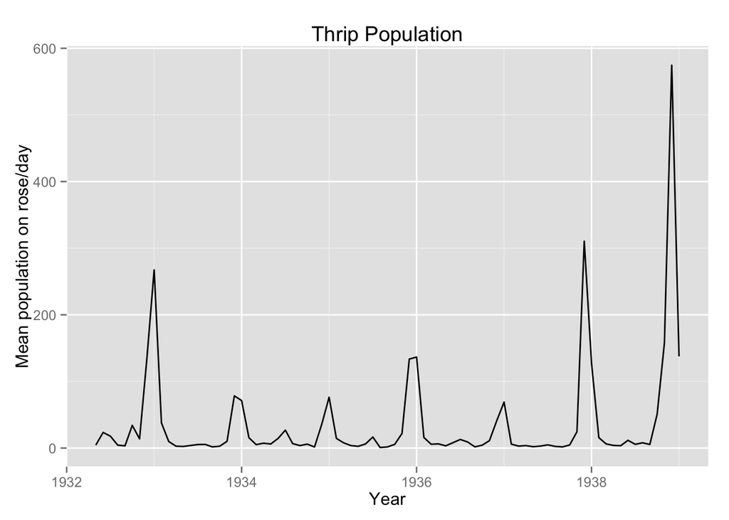

```r
require(ggplot2)
t_p<-ggplot(thrips,mapping=aes(x=time,y=pop))+geom_line()+ggtitle("Thrip Population")+xlab("Year")+ylab("Mean population on rose/day")

print(t_p)
```

[figure not shown]

```r
t_p+scale_y_log10()+ylab("Mean population on rose/day ( Log scale) ")
```

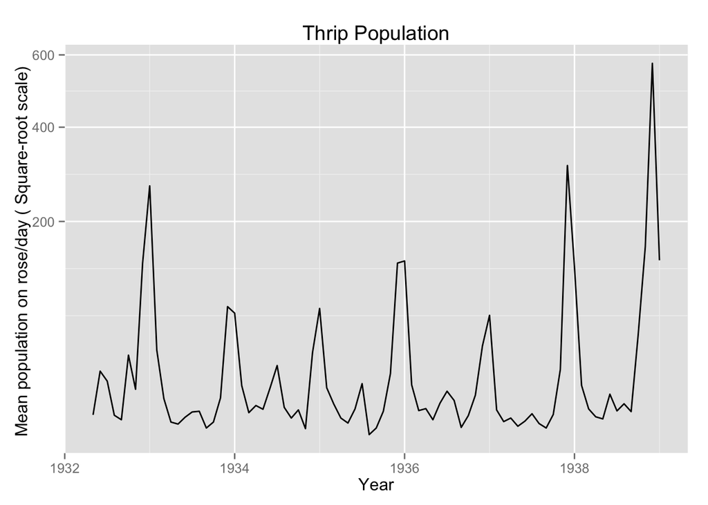

```r
t_p+scale_y_sqrt()+ylab("Mean population on rose/day ( Square-root scale) ")
```

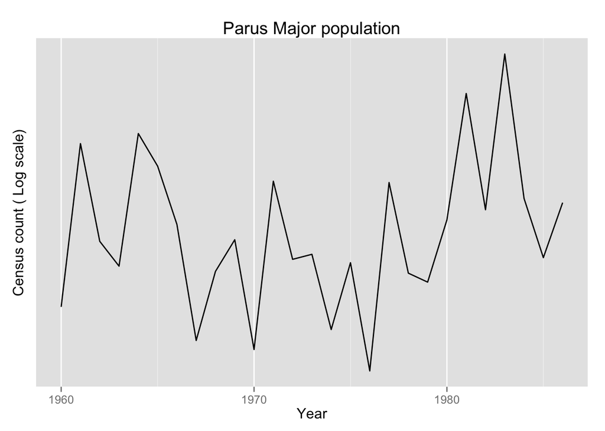

```r
p_p<-ggplot(parus,mapping=aes(x=year,y=pop))+geom_line()+ggtitle("Parus Major population")+xlab("Year")+ylab("Census count")
p_p+scale_y_log10()+ylab("Census count ( Log scale)")
```

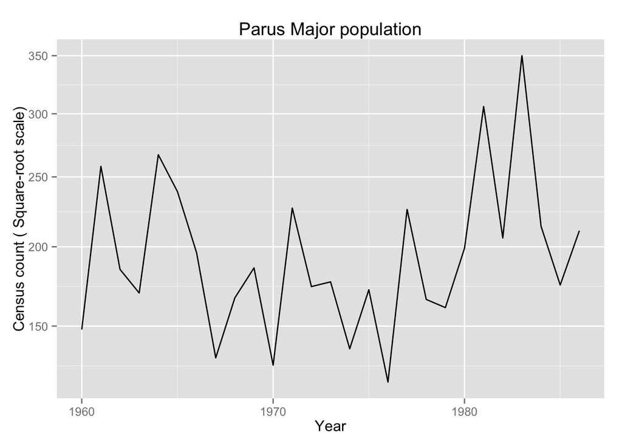

```r
p_p+scale_y_sqrt()+ylab("Census count ( Square-root scale)")
```